$\text{Michael Higgins and Sierra Wilde}$

# $$\text{Asking a statistical question}$$

## Problem 1:

### A).

I will make a sample of 100k data points using a Guassian distribution with a mean of $\mu=$12 and a $\sigma=$0.4 standard deviation. I will then splice in the "bad" data provided. The Guassian distribution is ${\displaystyle f(x\mid \mu ,\sigma ^{2})={\frac {1}{\sqrt {2\pi \sigma ^{2}}}}e^{-{\frac {(x-\mu )^{2}}{2\sigma ^{2}}}}}$

```python
import numpy as np
import matplotlib.pyplot as plt
import pandas as pd
from scipy import stats
```

```python
x = np.linspace(puretempdata.min(),puretempdata.max(),100000)
gpdf = stats.norm.pdf(x,loc=12,scale=0.4)


puretempdata = stats.norm.rvs(loc=12, scale = 0.4, size = 100000)

baddata = [10., 10.3, 2.1, 0., 0., 15.6, 22.3, 12.7]
altereddata = np.append(puretempdata,baddata)
```

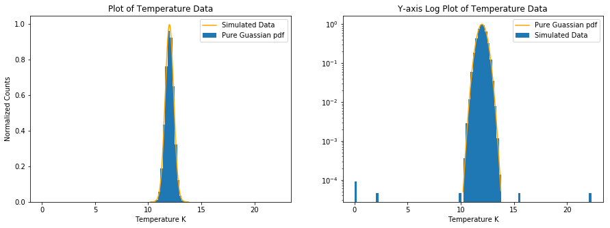

```python
fig,ax = plt.subplots(1,2,figsize=(15,5))

ax[0].set_title("Plot of Temperature Data")
ax[0].hist(altereddata,100,density=True,label = "Pure Guassian pdf");
ax[0].plot(x,gpdf,c='orange',label = 'Simulated Data')
ax[0].set_ylabel("Normalized Counts")
ax[0].set_xlabel("Temperature K")
ax[0].legend()

ax[1].set_title("Y-axis Log Plot of Temperature Data")
ax[1].hist(altereddata,100,density=True,label = 'Simulated Data')
ax[1].plot(x,gpdf,c='orange',label = "Pure Guassian pdf")
ax[1].set_yscale('log')
ax[1].set_xlabel("Temperature K")
ax[1].legend(loc='upper right');
```

Looking at my log plot of the temperature data over a perfect Guassian pdf it is apparent that a variety of counts for certain Temperatures are outliers since they fall well outside the curve of my Guassian pdf. Due to these outlier points we want to perform a statistical test to remove the bad points of data.

Statistical Question: With our experiment we expect the signal-free background to have a Guassian pdf with a mean of 12 K and a standard deviation of 0.4 K. We want to identify and eliminate points of our data when the thermal control system was not working since those points are errors are not representative of a good background. Which of our data points are statistically significant enough to no longer be considered a product of our background?

We ask this question to make sure we have (to the best of our ability) a good, error-free, accurate signal-free background.

Question in Math:

$$\int_{-\infty}^{-\chi} \frac {1}{\sqrt {2\pi \sigma ^{2}}}e^{-{\frac {(x-\mu )^{2}}{2\sigma ^{2}}}} = \frac{1-\mathrm{erf} \biggl(\frac{(\chi - \mu)}{\sqrt{2}\; \sigma}\biggr)}{2}$$

$$\int_{\chi}^{\infty} \frac {1}{\sqrt {2\pi \sigma ^{2}}}e^{-{\frac {(x-\mu )^{2}}{2\sigma ^{2}}}} = \frac{1-\mathrm{erf} \biggl(\frac{(\chi - \mu)}{\sqrt{2}\; \sigma}\biggr)}{2}$$

By taking the integral of our Guassian pdf from the left side of the tail from $-\infty$ to $-\chi$ and the right side of the tail from $\chi$ to $\infty$ where $\mu = 12$ and $\sigma =0.4$. Setting these integrals equal to the probability we deem significant will allow us to solve for $\chi$ and thus determine what values of temperature are significant enough to be considered as not caused by our background, and rather caused by some systematic. We often use 5$\sigma$ probability which is derived from a normal curve with a mean of 0 and standard deviation equal to 1 and finding what the probability is of having a value greater than or equal to 5 or less than or equal to -5(Since the normal distribution is symmetric about the mean). In the below equations I set $\chi_{1stdGuassian}$ to be equal to the number before the $\sigma$ so in our case it would be equal to 5 or -5 (for the 5 in $5\sigma$).

This means in order to find our $\chi$ we want the equation...

$$1-\mathrm{erf} \biggl(\frac{(\chi - \mu)}{\sqrt{2}\; \sigma}\biggr) = 1-\mathrm{erf} \biggl(\frac{\chi_{1stdGuassian}}{\sqrt{2}}\biggr)$$

$$\mathrm{erf} \biggl(\frac{(\chi - \mu)}{\sqrt{2}\; \sigma}\biggr) = \mathrm{erf} \biggl(\frac{\chi_{1stdGuassian}}{\sqrt{2}}\biggr)$$

$$\frac{(\chi - \mu)}{ \sigma} = \chi_{1stdGuassian}$$

Plugging in our values listed above we find that any temperature greater than 14 or less than 10 are considered statistically signficant enough to remove as bad data. More generally we have the range below. $$\chi = \mu \pm \sigma \chi_{1stdGuassian} $$

```python
sigma=5

goodkept = puretempdata[np.where((puretempdata< 12+sigma*.4) & (puretempdata> 12-sigma*.4))]
gooddiscard = len(puretempdata) - len(goodkept)

baddata = np.asarray(baddata)
badkept = baddata[np.where((baddata>12-sigma*.4) & (baddata<12+sigma*.4))]
baddiscard = len(baddata) - len(badkept)

truth_table = pd.DataFrame(np.array([[len(goodkept),len(badkept)],[gooddiscard,baddiscard]]),index = ['Kept','Discarded'], columns=['Good Data', 'Bad Data'])
```

```python
truth_table
```

|  | Good Data | Bad Data |
| --- | --- | --- |
| Kept | 100000 | 2 |
| Discarded | 0 | 6 |

This is my truth table for a $5\sigma$ statistical significance probability. We kept all of the good data, but also 2 points of bad data.

### C).

There are mistakes of commission. They are avoidable by making our statistical threshold($\chi_{1stdGuassian}$) smaller. This comes at a cost detailed in B). If we decrease our threshold to 1$\sigma$ then we would also be removing 32% of our good data. We would want to find a way to maximize the percent of good data kept while minimizing the mistakes of commission. So while decreasing our statistical threshold minimizes our mistakes of commission it also minimizes our percent of good data omitted. So in short, it is possible to minimize our mistakes of commission to 0 but it will eventually come at the cost of also getting rid of our good data.

## Problem 2:

Question in Words: In order to determine whether we have detected an asteroid we need to show that the change in arcseconds between the images is statistically significant. Given a 2 dimensional Guassian distribution with a mean of 0 and a standard deviation of 1 arc second as our signal-free background, at what movements of ($\Delta x,\Delta y $) would have a 5$\sigma$ probability of occuring from our background and could thus be determined to be caused by potential asteroids?

Question in Math:

Since this is a rotationally symmetric distribution it is relatively easy for us to find an equation that would output a statistically significant pair of ($\Delta x,\Delta y$).

Taking the points where $\Delta y = 0$ in our pdf we can find what arcsecond values for $\Delta x$ would be considered 5$\sigma$ statistically significant(This is done by integrating our 1-D Guassian pdf). Using the fact that the distribution is angularly symmetric this would mean that at any point where $\sqrt{\Delta x^2 + \Delta y^2} \geq \Delta x_{0}$ would be statistically significant.

$$\int_{\Delta x_0}^{\infty} \frac {1}{\sqrt {2\pi \sigma ^{2}}}e^{-{\frac {(x-\mu )^{2}}{2\sigma ^{2}}}} = \frac{1-\mathrm{erf} \biggl(\frac{(\Delta x_0 - \mu)}{\sqrt{2}\; \sigma}\biggr)}{2} = \frac{1-\mathrm{erf} \biggl(\frac{(\chi - \mu)}{\sqrt{2}\; \sigma}\biggr)}{2}$$

$$\mathrm{erf} \biggl(\frac{(\Delta x_0 - \mu)}{\sqrt{2}\; \sigma}\biggr) = \mathrm{erf} \biggl(\frac{(\chi - \mu)}{\sqrt{2}\; \sigma}\biggr)$$

$$\Delta x_0 = \chi \sigma$$

Setting $\chi$ equal to 5, $\mu$ equal to 0, and $\sigma$ equal to 1 we can find what our $\Delta x_0$ is when $\Delta y =0$.

$$\boxed{ \Delta x_0 = 5 \text{ arcseconds}}$$

$$\boxed{ \sqrt{\Delta x^2 + \Delta y^2} \geq 5 \text{ arcseconds}}$$

$$\text{This is where we would say we detected an asteroid}$$

## Problem 3:

Question in Words: We expect the moon to effectively shadow the Earth from cosmic $\gamma$ rays. In a moon sized patch of the sky we expect to see 1 $\gamma$ ray a minute and this effectively gives us a Poisson background pdf. Assuming a Poisson signal-free background pdf with $\mu$ equal to 1 cosmic ray per minute, what is the significance of detecting 6,800 counts of $\gamma$ rays after 7,200 minutes of observing the moon?

In math: This is a number of trials problem. So what we need to do is find our background pdf for a single minute and then multiply that by the 7,200 minutes of observing the moon to get the proper background pdf. Then to get the probability that we observe 6,800 or less counts of $\gamma$ rays we would integrate our proper background pdf from -$\infty$ to 6,800. Then we find what value of sigma that occurs for a standard normal distribution.

$$\mathrm{pdf}_{1minute}(k) = \frac{e^{-\mu}\mu^k}{k!} = \frac{1}{ek!}$$

$$\mathrm{Proper\ pdf}(k)= \frac{7200}{ek!} $$

$$P(k \leq 6800) = 7200 \cdot \int_{-\infty}^{6800} \mathrm{pdf}_{1minute}(k) dk =7200 \cdot \int_{-\infty}^{6800} \frac{e^{-\mu}\mu^k}{k!} dk = \int_{-\infty}^{6800} \frac{7200}{ek!}dk$$

```
(0, 150000)
```

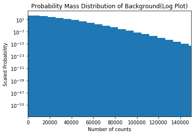

```python
k1 = np.arange(0,50)


ppmf1 = stats.poisson.pmf(k1,1)
ppmf2 = 7200 * ppmf1

plt.bar(k1*7200,ppmf2, width = 7200*(k1[2]-k1[1]))
plt.yscale('log')
plt.title('Probability Mass Distribution of Background(Log Plot)')
plt.ylabel('Scaled Probability')
plt.xlabel('Number of counts')
plt.xlim(0,150000)
```

$$P(k \leq 6800) = \int_{\chi}^{\infty} \frac {1}{\sqrt {2\pi \sigma ^{2}}}e^{-{\frac {x^{2}}{2\sigma ^{2}}}} = \frac{1-\mathrm{erf} \biggl(\frac{\chi}{\sqrt{2}\;}\biggr)}{2}$$

Solving for $\chi$ will give us the $\chi \sigma$ probability of our background having 6,800 counts or less.

```python
probability = ppmf2[np.where(k1*7200<=6800)].sum()/7200

chi = stats.norm.isf(probability)
print('The sigma value of getting 6800 counts or less over a 7200 time interval is {0:.3f}'.format(chi))
```

```
The sigma value of getting 6800 counts or less over a 7200 time interval is 0.337
```

Since there is a .337$\sigma$ probability of 6,800 counts being created from our background we can not say the moon shrouds the Earth significantly from $\gamma$ rays.